# Dimensionality reduction

Suvi

November 30, 2018

```r
library(ggplot2)
library(dplyr)
library(GGally)
library(MASS)
library(tidyr)
library(boot)
library(corrplot)
library(FactoMineR)

data <- read.csv("human.csv", header = T, row.names = 1)
rownames(data) <- data[, 1] ## set rownames
data <- data[, -1]          ## remove the first variable
summary(data)
```

[output not shown]

Graphical overview of the data

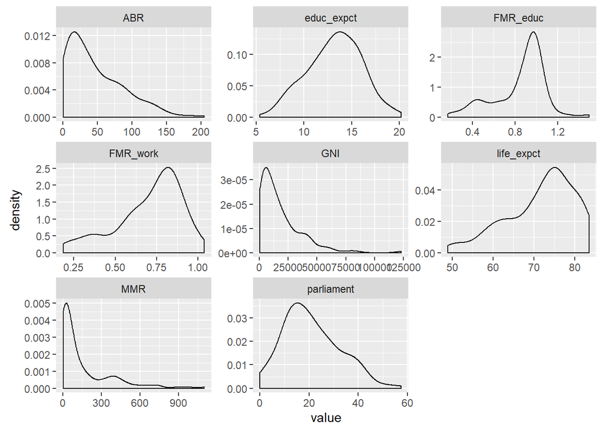

```r
gather(data) %>% ggplot(aes(value)) + facet_wrap("key", scales = "free") + geom_density()
```

Most variables have rather skewed distributions, except for Expected years of schooling and Percetange of female representatives in parliament. Majority of the countries have relatively low adolescent birth rate. Mean of expected years of education is 13 years, and most of the countries have expected years of eductaion in the range of 11-15 years. Life expectancy is on averge 71 years. Female to male-ratio in the proportion of individuals with at least secondary level education is around 0.85 meaning that, on average, women receive less education than men. Famale to male-ratio in participation in the work force is lower, approximately 0.70. Maternal mortality rate is low in most of the countries, but the range of the distribution is large. The average proportion of the female representatives in parliament is 20%.

```r
# calculate the correlation matrix and round it
cor_matrix<-cor(data) %>% round(digits=2)

# print the correlation matrix
cor_matrix
```

```
##            FMR_educ FMR_work life_expct educ_expct   GNI   MMR   ABR
## FMR_educ       1.00     0.01       0.58       0.59  0.43 -0.66 -0.53
## FMR_work       0.01     1.00      -0.14       0.05 -0.02  0.24  0.12
## life_expct     0.58    -0.14       1.00       0.79  0.63 -0.86 -0.73
## educ_expct     0.59     0.05       0.79       1.00  0.62 -0.74 -0.70
## GNI            0.43    -0.02       0.63       0.62  1.00 -0.50 -0.56
## MMR           -0.66     0.24      -0.86      -0.74 -0.50  1.00  0.76
## ABR           -0.53     0.12      -0.73      -0.70 -0.56  0.76  1.00
## parliament     0.08     0.25       0.17       0.21  0.09 -0.09 -0.07
##            parliament
## FMR_educ         0.08
## FMR_work         0.25
## life_expct       0.17
## educ_expct       0.21
## GNI              0.09
## MMR             -0.09
## ABR             -0.07
## parliament       1.00
```

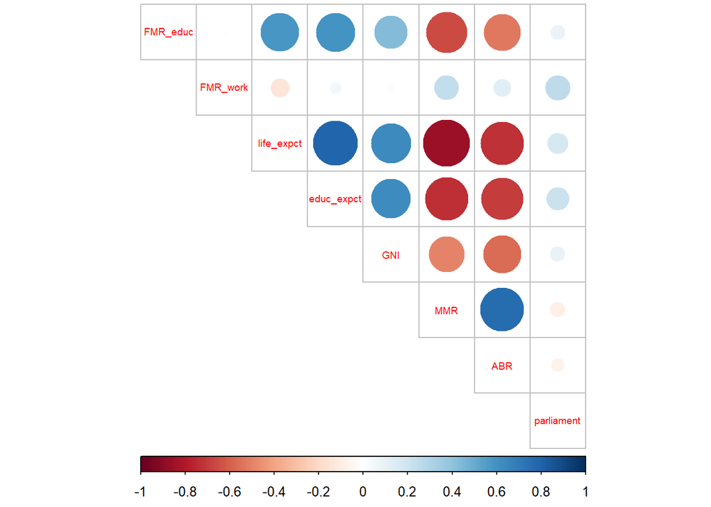

```r
# visualize the correlation matrix
corrplot(cor_matrix, method="circle", type="upper", cl.pos = "b", tl.pos = "d",tl.cex = 0.6)
```

There are large negative as well as positive correlations between the variables. Higher life expectancy and years or education are associated with lower maternal mortality rate and adolescent birth rate. Higher life expectancy predicts more years of education, and higher Gross National Income per capita. Increase in female to male-ratio in secondary education is associated with increase in life expectancy and and years of education.

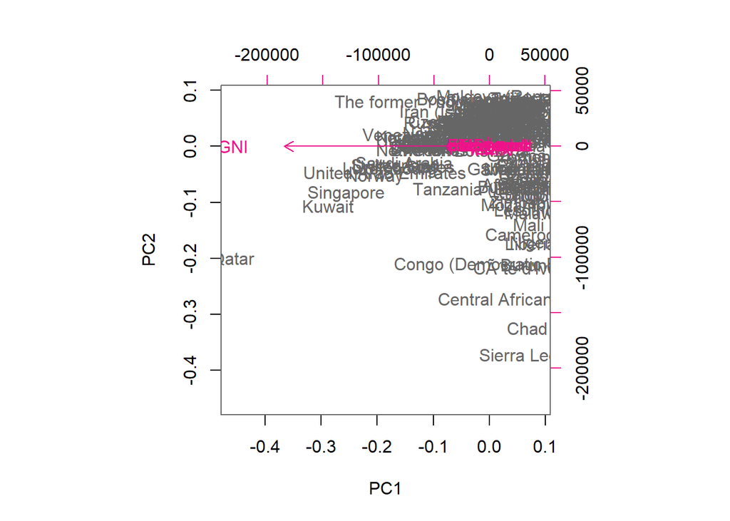

```r
# perform principal component analysis (with the SVD method)
pca_human <- prcomp(data)

# draw a biplot of the principal component representation and the original variables
biplot(pca_human, choices = 1:2,cex = c(1, 1),col = c("grey40", "deeppink2"))
```

```r
#summary of pc2
pca_human$rotation
```

```
##                      PC1           PC2           PC3           PC4
## FMR_educ   -5.607472e-06  0.0006713951 -3.412027e-05 -2.736326e-04
## FMR_work    2.331945e-07 -0.0002819357  5.302884e-04 -4.692578e-03
## life_expct -2.815823e-04  0.0283150248  1.294971e-02 -6.752684e-02
## educ_expct -9.562910e-05  0.0075529759  1.427664e-02 -3.313505e-02
## GNI        -9.999832e-01 -0.0057723054 -5.156742e-04  4.932889e-05
## MMR         5.655734e-03 -0.9916320120  1.260302e-01 -6.100534e-03
## ABR         1.233961e-03 -0.1255502723 -9.918113e-01  5.301595e-03
## parliament -5.526460e-05  0.0032317269 -7.398331e-03 -9.971232e-01
##                      PC5           PC6           PC7           PC8
## FMR_educ   -0.0022935252  2.180183e-02  6.998623e-01  7.139410e-01
## FMR_work    0.0022190154  3.264423e-02  7.132267e-01 -7.001533e-01
## life_expct  0.9865644425 -1.453515e-01  5.380452e-03  2.281723e-03
## educ_expct  0.1431180282  9.882477e-01 -3.826887e-02  7.776451e-03
## GNI        -0.0001135863 -2.711698e-05 -8.075191e-07 -1.176762e-06
## MMR         0.0266373214  1.695203e-03  1.355518e-04  8.371934e-04
## ABR         0.0188618600  1.273198e-02 -8.641234e-05 -1.707885e-04
## parliament -0.0716401914 -2.309896e-02 -2.642548e-03  2.680113e-03
```

```r
# create and print out a summary of pca_human
s <- summary(pca_human)
s
```

```
## Importance of components:
##                              PC1      PC2   PC3   PC4   PC5   PC6    PC7
## Standard deviation     1.854e+04 185.5219 25.19 11.45 3.766 1.566 0.1912
## Proportion of Variance 9.999e-01   0.0001  0.00  0.00 0.000 0.000 0.0000
## Cumulative Proportion  9.999e-01   1.0000  1.00  1.00 1.000 1.000 1.0000
##                           PC8
## Standard deviation     0.1591
## Proportion of Variance 0.0000
## Cumulative Proportion  1.0000
```

```r
# rounded percetanges of variance captured by each PC
pca_pr <- round(1*s$importance[2, ], digits = 5)

# print out the percentages of variance
pca_pr
```

```
##    PC1    PC2    PC3    PC4    PC5    PC6    PC7    PC8
## 0.9999 0.0001 0.0000 0.0000 0.0000 0.0000 0.0000 0.0000
```

Looks like PC1 explains nearly 100% of the variation. GNI and all other variables appear as if virtually orthagonal, which seems unlikely.  
**Standardizing variables**

```r
# standardize the variables
human_std <- scale(data)

# print out summaries of the standardized variables
summary(human_std)
```

```
##     FMR_educ          FMR_work         life_expct        educ_expct
##  Min.   :-2.8189   Min.   :-2.6247   Min.   :-2.7188   Min.   :-2.7378
##  1st Qu.:-0.5233   1st Qu.:-0.5484   1st Qu.:-0.6425   1st Qu.:-0.6782
##  Median : 0.3503   Median : 0.2316   Median : 0.3056   Median : 0.1140
##  Mean   : 0.0000   Mean   : 0.0000   Mean   : 0.0000   Mean   : 0.0000
##  3rd Qu.: 0.5958   3rd Qu.: 0.7350   3rd Qu.: 0.6717   3rd Qu.: 0.7126
##  Max.   : 2.6646   Max.   : 1.6632   Max.   : 1.4218   Max.   : 2.4730
##       GNI               MMR               ABR            parliament
##  Min.   :-0.9193   Min.   :-0.6992   Min.   :-1.1325   Min.   :-1.8203
##  1st Qu.:-0.7243   1st Qu.:-0.6496   1st Qu.:-0.8394   1st Qu.:-0.7409
##  Median :-0.3013   Median :-0.4726   Median :-0.3298   Median :-0.1403
##  Mean   : 0.0000   Mean   : 0.0000   Mean   : 0.0000   Mean   : 0.0000
##  3rd Qu.: 0.3712   3rd Qu.: 0.1932   3rd Qu.: 0.6030   3rd Qu.: 0.6127
##  Max.   : 5.6890   Max.   : 4.4899   Max.   : 3.8344   Max.   : 3.1850
```

```r
# perform principal component analysis (with the SVD method)
pca2_human <- prcomp(human_std)

#summary of pc2
pca2_human$rotation
```

```
##                    PC1         PC2         PC3         PC4        PC5
## FMR_educ   -0.35664370  0.03796058 -0.24223089  0.62678110 -0.5983585
## FMR_work    0.05457785  0.72432726 -0.58428770  0.06199424  0.2625067
## life_expct -0.44372240 -0.02530473  0.10991305 -0.05834819  0.1628935
## educ_expct -0.42766720  0.13940571 -0.07340270 -0.07020294  0.1659678
## GNI        -0.35048295  0.05060876 -0.20168779 -0.72727675 -0.4950306
## MMR         0.43697098  0.14508727 -0.12522539 -0.25170614 -0.1800657
## ABR         0.41126010  0.07708468  0.01968243  0.04986763 -0.4672068
## parliament -0.08438558  0.65136866  0.72506309  0.01396293 -0.1523699
##                    PC6         PC7         PC8
## FMR_educ    0.17713316  0.05773644  0.16459453
## FMR_work   -0.03500707 -0.22729927 -0.07304568
## life_expct -0.42242796 -0.43406432  0.62737008
## educ_expct -0.38606919  0.77962966 -0.05415984
## GNI         0.11120305 -0.13711838 -0.16961173
## MMR         0.17370039  0.35380306  0.72193946
## ABR        -0.76056557 -0.06897064 -0.14335186
## parliament  0.13749772  0.00568387 -0.02306476
```

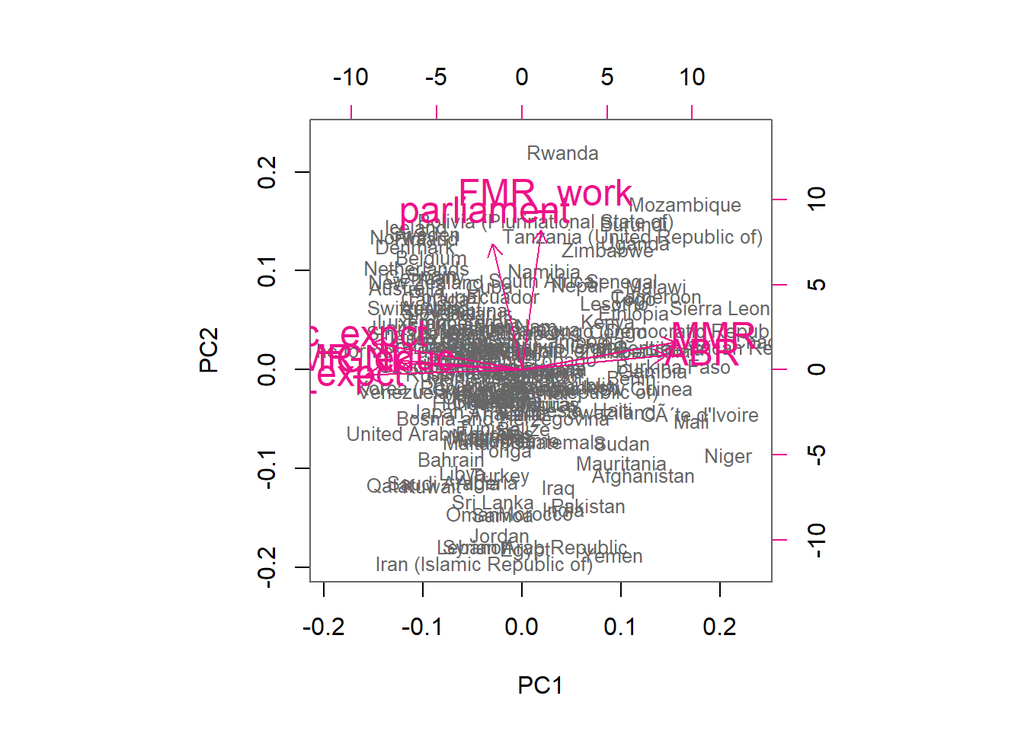

```r
# draw a biplot of the principal component representation and the original variables
biplot(pca2_human, choices = 1:2,cex = c(0.8, 1.5),col = c("grey40", "deeppink2"))
```

```r
# create and print out a summary of pca_human
s <- summary(pca2_human)
s
```

```
## Importance of components:
##                           PC1    PC2     PC3     PC4     PC5     PC6
## Standard deviation     2.0708 1.1397 0.87505 0.77886 0.66196 0.53631
## Proportion of Variance 0.5361 0.1624 0.09571 0.07583 0.05477 0.03595
## Cumulative Proportion  0.5361 0.6984 0.79413 0.86996 0.92473 0.96069
##                            PC7     PC8
## Standard deviation     0.45900 0.32224
## Proportion of Variance 0.02634 0.01298
## Cumulative Proportion  0.98702 1.00000
```

```r
# rounded percetanges of variance captured by each PC
pca2_pr <- round(1*s$importance[2, ], digits = 5)

# print out the percentages of variance
pca2_pr
```

```
##     PC1     PC2     PC3     PC4     PC5     PC6     PC7     PC8
## 0.53605 0.16237 0.09571 0.07583 0.05477 0.03595 0.02634 0.01298
```

The biplot looks quite different in the normalized data. The first PCA did not work very well, since some of the variables had a large variance and some small. The PCA will load on the large variances, which is why there was one component dominating the rest.

There appears to be at least 3 relevant principal components. The first relates to maternal mortality rate and adolescent birth rate. They are closely associated, which makes sense given that in e.g. in developing countries both adolescenct pregnancies and death during childbirth are relatively common, at least in part due to women’s position in the society and the lack of access to medical care. Giving birth while very young may also increase the risk of dying during childbirth. This component coud represent something such as state of the women’s reproductive health in the country.

The second component includes ratio of women to men in the work force. I would interpret this as the component representing opportunities for women to have economic independence/influence outside the home sphere.

The third component is not quite the same, but rather close to the component with female-to-male ratio in the work force. The proportion of women in the parliament might represent how much women have political power/opportunities to have inluence on politics in the country.

**TEA DATA**

```r
data(tea)

# column names to keep in the dataset
keep_columns <- c("Tea", "How", "how", "sugar", "where", "lunch")

# select the 'keep_columns' to create a new dataset
tea_time <- dplyr::select(tea, one_of(keep_columns))

str(tea_time)
```

```
## 'data.frame':    300 obs. of  6 variables:
##  $ Tea  : Factor w/ 3 levels "black","Earl Grey",..: 1 1 2 2 2 2 2 1 2 1 ...
##  $ How  : Factor w/ 4 levels "alone","lemon",..: 1 3 1 1 1 1 1 3 3 1 ...
##  $ how  : Factor w/ 3 levels "tea bag","tea bag+unpackaged",..: 1 1 1 1 1 1 1 1 2 2 ...
##  $ sugar: Factor w/ 2 levels "No.sugar","sugar": 2 1 1 2 1 1 1 1 1 1 ...
##  $ where: Factor w/ 3 levels "chain store",..: 1 1 1 1 1 1 1 1 2 2 ...
##  $ lunch: Factor w/ 2 levels "lunch","Not.lunch": 2 2 2 2 2 2 2 2 2 2 ...
```

```r
dim(tea_time)
```

```
## [1] 300   6
```

Graphical overview

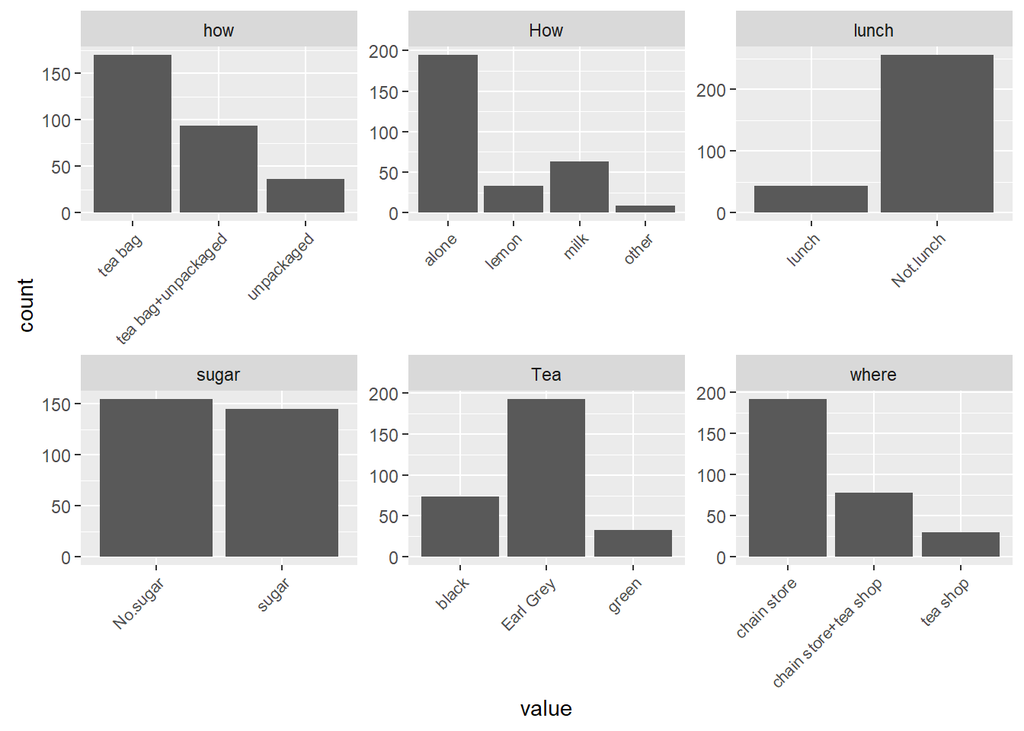

```r
# visualize the dataset
b <- gather(tea_time) %>% ggplot(aes(value)) + facet_wrap("key", scales = "free") + theme(axis.text.x = element_text(angle = 45, hjust = 1, size = 8))

b + geom_bar()
```

```r
# multiple correspondence analysis
mca <- MCA(tea_time, graph = FALSE)

# summary of the model
summary(mca)
```

```
##
## Call:
## MCA(X = tea_time, graph = FALSE)
##
##
## Eigenvalues
##                        Dim.1   Dim.2   Dim.3   Dim.4   Dim.5   Dim.6
## Variance               0.279   0.261   0.219   0.189   0.177   0.156
## % of var.             15.238  14.232  11.964  10.333   9.667   8.519
## Cumulative % of var.  15.238  29.471  41.435  51.768  61.434  69.953
##                        Dim.7   Dim.8   Dim.9  Dim.10  Dim.11
## Variance               0.144   0.141   0.117   0.087   0.062
## % of var.              7.841   7.705   6.392   4.724   3.385
## Cumulative % of var.  77.794  85.500  91.891  96.615 100.000
##
## Individuals (the 10 first)
##                       Dim.1    ctr   cos2    Dim.2    ctr   cos2    Dim.3
## 1                  | -0.298  0.106  0.086 | -0.328  0.137  0.105 | -0.327
## 2                  | -0.237  0.067  0.036 | -0.136  0.024  0.012 | -0.695
## 3                  | -0.369  0.162  0.231 | -0.300  0.115  0.153 | -0.202
## 4                  | -0.530  0.335  0.460 | -0.318  0.129  0.166 |  0.211
## 5                  | -0.369  0.162  0.231 | -0.300  0.115  0.153 | -0.202
## 6                  | -0.369  0.162  0.231 | -0.300  0.115  0.153 | -0.202
## 7                  | -0.369  0.162  0.231 | -0.300  0.115  0.153 | -0.202
## 8                  | -0.237  0.067  0.036 | -0.136  0.024  0.012 | -0.695
## 9                  |  0.143  0.024  0.012 |  0.871  0.969  0.435 | -0.067
## 10                 |  0.476  0.271  0.140 |  0.687  0.604  0.291 | -0.650
##                       ctr   cos2
## 1                   0.163  0.104 |
## 2                   0.735  0.314 |
## 3                   0.062  0.069 |
## 4                   0.068  0.073 |
## 5                   0.062  0.069 |
## 6                   0.062  0.069 |
## 7                   0.062  0.069 |
## 8                   0.735  0.314 |
## 9                   0.007  0.003 |
## 10                  0.643  0.261 |
##
## Categories (the 10 first)
```

[output cut: 16 more lines]

```
## lemon                0.035   3.226 |   1.329  14.771   0.218   8.081 |
## milk                 0.020   2.422 |   0.013   0.003   0.000   0.116 |
## other                0.102   5.534 |  -2.524  14.526   0.197  -7.676 |
## tea bag              0.161  -6.941 |  -0.065   0.183   0.006  -1.287 |
## tea bag+unpackaged   0.478  11.956 |   0.019   0.009   0.000   0.226 |
## unpackaged           0.141  -6.482 |   0.257   0.602   0.009   1.640 |
##
## Categorical variables (eta2)
##                      Dim.1 Dim.2 Dim.3
## Tea                | 0.126 0.108 0.410 |
## How                | 0.076 0.190 0.394 |
## how                | 0.708 0.522 0.010 |
## sugar              | 0.065 0.001 0.336 |
## where              | 0.702 0.681 0.055 |
## lunch              | 0.000 0.064 0.111 |
```

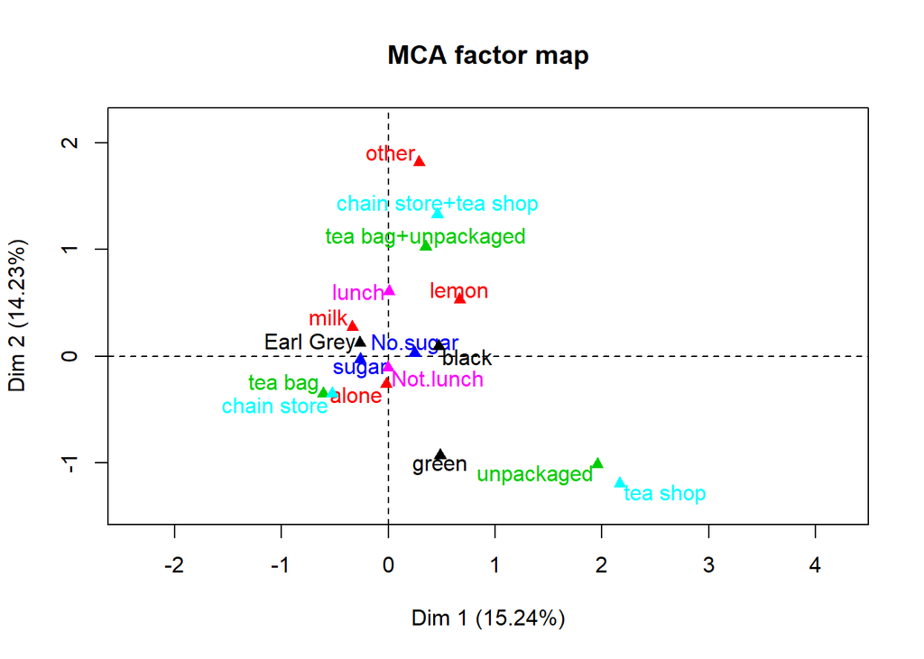

```r
# visualize MCA
plot(mca, invisible=c("ind"), habillage = "quali")
```

Looking at the visualization of the MCA, it appears that people who bought their tea from tea shops, were more likely to brink unpackaged tea than other types. They may have preferred green tea as well. Those who bought from the chain store, usually used tea bags. Then there was a group which did not really have a preference - they bought from the store as well as tea shops, and drank packaged and unpackaged teas. Many also drank lemon tea.